# BS8 and BS10

2024-01-02

# A

## 1.

We fit a Poisson model to the data under the assumption that $Y_i \sim poiss(\lambda)$ are i.i.d. Recall that the poisson family uses the log-link by default. We can specify the identity link to get on normal scale

```r
fitted <- glm(y ~ 1, family = poisson("identity"), data = before)
fitted
```

```
##
## Call:  glm(formula = y ~ 1, family = poisson("identity"), data = before)
##
## Coefficients:
## (Intercept)
##       9.586
##
## Degrees of Freedom: 168 Total (i.e. Null);  168 Residual
## Null Deviance:       225.8
## Residual Deviance: 225.8     AIC: 910.7
```

```r
fitted %>% coef()
```

```
## (Intercept)
##    9.585799
```

## 2.

Up to proportionality the likelihood for $(y_1, y_2, \cdots, y_n)$ given $\lambda$ is
$$p(y|\lambda) = \prod_{i = 1}^n \frac{\lambda^{y_i}}{y_i!}\exp(\lambda)
\propto \lambda^{\sum_{i = 1}^n y_i} \exp(-n\lambda) = \lambda^{n
\bar{y}} \exp(-n\lambda)$$
With $\bar{y}$ the average of the $y$’s. This shows that $\bar{y}$ is sufficient. If we have a uniform prior on $\lambda$ the posterior is
$$p(\lambda| \bar{y}) \propto \lambda^{n \bar{y}} \exp(-n\lambda)$$
Which we recognise as an unnormalized $\Gamma(n\bar{y} +1, n)$ distribution in the shape-rate parametrization. We can the simulate from the posterior to compute a credible interval and posterior mean

```r
ybar <- before$y %>% mean()
n <- nrow(before)
m <- 10000
lambda_sim <- rgamma(m, n*ybar+1, n)
mean(lambda_sim)
```

```
## [1] 9.591197
```

```r
quantile(lambda_sim, c(0.025, 0.975))
```

```
##      2.5%     97.5%
##  9.143179 10.064658
```

## 4.

Let $\bar{Y}_j$ be the killed drivers after the law is passed and let these also be i.i.d. with the old ones. Consider $Z$ to be the total number of killed drivers after law is passed. Since sums of independent poisson random variables and there are 23 observations, $Z \sim pois(23\lambda)$. We simulate $Z$ from the prior predictive, by first using our simulated lambdas, and then simulating Z from the relevant poisson distribution. We find the 0.1, 1 and 5 pct quantile.

```r
quantile(rpois(m, 23*lambda_sim), c(0.001,0.01,0.05))
```

```
## 0.1%   1%   5%
##  174  184  195
```

## 5.

Under the above model considerations it is absurd to observe only the actual observed 119 deaths. This tells us that there should be an effect of the law.

## 6.

There seems to be a general downward trend for each year even before the law is passed, which is of course problematic when we assume that the rate is constant throughout years, and it muddys our conclusion on the effect of the law.

## 7.

We do MCMC

```r
brm1A <- brm(y ~ 1, family=poisson(link="log"), data=before,
warmup = 500, iter = 1500, chains = 4, refresh = 0)
summary <- brm1A %>% summary()
exp(summary$fixed)
```

```
##           Estimate Est.Error l-95% CI u-95% CI     Rhat Bulk_ESS Tail_ESS
## Intercept 9.589878  1.024878 9.136486 10.05311 2.721812      Inf      Inf
```

```r
brm1A$prior
```

```
## Intercept ~ student_t(3, 2.3, 2.5)
```

## 8.

We can also do uniform priors.

```r
brm1B <- brm(y ~ 1, family=poisson(), data=before,
prior = c(set_prior("uniform(-1000,1000)",
class="Intercept", lb=-1000, ub=1000)),
warmup = 500, iter = 1500, chains = 4, refresh = 0)
brm1B$prior
```

```
## <lower=-1000,upper=1000> Intercept ~ uniform(-1000,1000)
```

```r
brm1B %>% summary()
```

```
##  Family: poisson
##   Links: mu = log
## Formula: y ~ 1
##    Data: before (Number of observations: 169)
##   Draws: 4 chains, each with iter = 1500; warmup = 500; thin = 1;
##          total post-warmup draws = 4000
##
## Population-Level Effects:
##           Estimate Est.Error l-95% CI u-95% CI Rhat Bulk_ESS Tail_ESS
## Intercept    62.72     60.56     2.22   128.20 2.31        5       11
##
## Draws were sampled using sampling(NUTS). For each parameter, Bulk_ESS
## and Tail_ESS are effective sample size measures, and Rhat is the potential
## scale reduction factor on split chains (at convergence, Rhat = 1).
```

```r
brm1C <- brm(y ~ 1, family=poisson(link="identity"), data=before,
prior = c(set_prior("uniform(-1000,1000)",
class="Intercept", lb=-1000, ub=1000)),
warmup = 500, iter = 1500, chains = 4, refresh = 0)
brm1C$prior
```

```
## <lower=-1000,upper=1000> Intercept ~ uniform(-1000,1000)
```

```r
brm1C %>% summary()
```

```
##  Family: poisson
##   Links: mu = identity
## Formula: y ~ 1
##    Data: before (Number of observations: 169)
##   Draws: 4 chains, each with iter = 1500; warmup = 500; thin = 1;
##          total post-warmup draws = 4000
##
## Population-Level Effects:
##           Estimate Est.Error l-95% CI u-95% CI Rhat Bulk_ESS Tail_ESS
## Intercept     9.60      0.24     9.14    10.08 1.00     1340     1768
##
## Draws were sampled using sampling(NUTS). For each parameter, Bulk_ESS
## and Tail_ESS are effective sample size measures, and Rhat is the potential
## scale reduction factor on split chains (at convergence, Rhat = 1).
```

Again the difference between the two models is the link function used. Obviously we want the identity link to if we want a uniform prior on the $\lambda$ and not on the log-link scale. We might also run into numerical troubles on the log-link scale since we are taking a uniform interval over $[-1000,1000]$ and $e^{1000}$ is very, very large.

# B

We now assume that before the law $Y_i \sim pois(\lambda_i)$ with $\log(\lambda_i) = \alpha + \beta x_i$ with $x_i$ the number of months since data collection began. $Y_i$ are independent given the parameters

## 9.

The ML estimates for $\alpha$ and $\beta$ are computed with

```r
glm(y ~ x, family = poisson("log"), data = before) %>% coef()
```

```
##  (Intercept)            x
##  2.542810981 -0.003494311
```

## 10.

```r
brm2 <- brm(y ~ x, family=poisson(link="log"), data=before,
prior = c(set_prior("normal(0,1)", class = "b", coef = "x"),
set_prior("normal(3,25)", class="Intercept")),
warmup = 500, iter = 1500, chains = 4,
refresh=1)
sim2 <- as.data.frame(brm2) %>% tibble()
```

The posterior means and intervals are calculated for $\beta$

```r
quantile(sim2$b_x, c(0.025, 0.975)) # -0.004497502 -0.002516153
```

```
##         2.5%        97.5%
## -0.004457662 -0.002511837
```

```r
mean(sim2$b_x) #-0.003501322
```

```
## [1] -0.00348568
```

## 11.

Assume that the downward trend stays the same after the law has been passed, and that there is no effect of the law. Let $\bar{Y}_j$ be the killed drivers after the law is passed in each month and let $Z$ to be the total number of killed drivers after law is passed, i.e. $Z = \sum \bar{Y}_j$. Given $\alpha$ and $\beta$ $\bar{Y}_j \sim \pois(\lambda_j)$ with $\log(\lambda_j) = \alpha + \beta x_j$. Hence we can make draws from $Z$ by drawing for each simulated $\alpha$ and $\beta$ all $\bar{Y}_j$ and summing these to get $Z$.

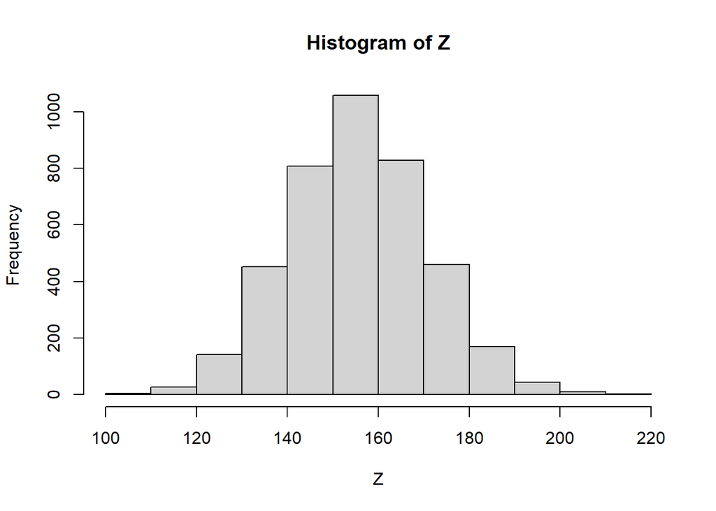

```r
Z <- numeric(nrow(sim2))
for(i in 1:nrow(sim2)){
  alpha <- sim2[i,"b_Intercept"] %>% as.numeric()
  beta <- sim2[i,"b_x"] %>% as.numeric()
  lambda <- exp(after$x*beta + alpha)
  bar_Y <- rpois(length(lambda), lambda)
  Z[i] <- sum(bar_Y)
  }
hist(Z)
```

## 12.

Under the assumptions above we can compute how likely it is to observe 119 or fewer killings,

```r
mean(Z <= 119)
```

```
## [1] 0.0055
```

This is still a low probability but not nearly as extreme as the one observed in question 5.

# C

## 1.

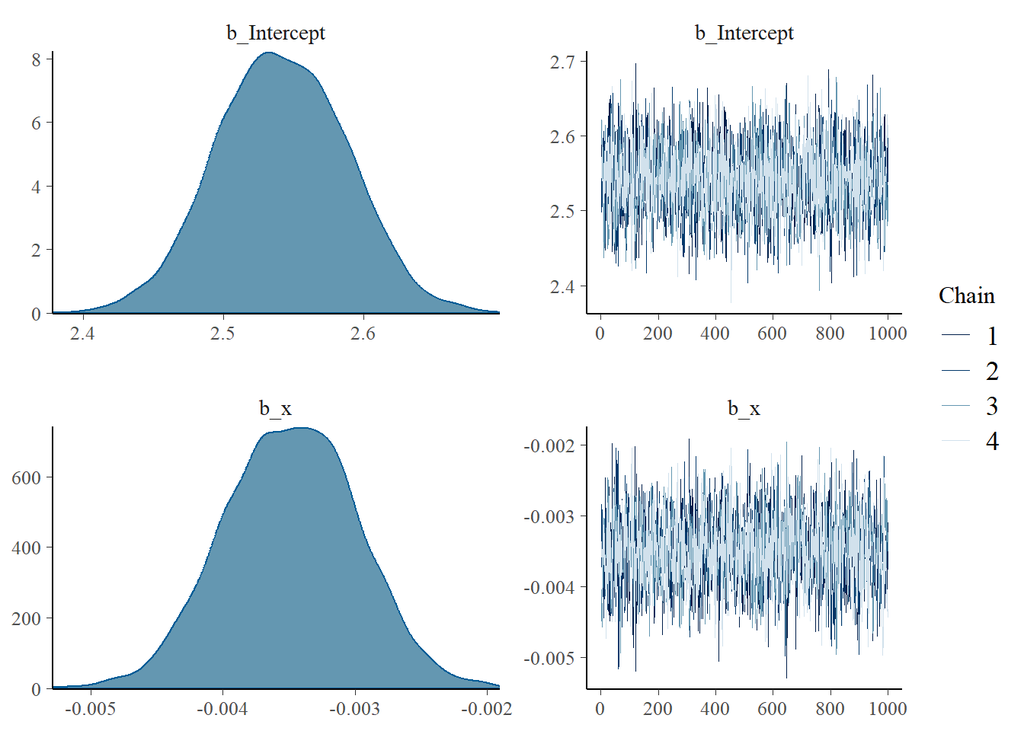

```r
plot(brm2)
```

This looks completely random/stable, no trends and no significant difference between chains. Very happy.

## 2.

```r
summary(brm2)
```

```
##  Family: poisson
##   Links: mu = log
## Formula: y ~ x
##    Data: before (Number of observations: 169)
##   Draws: 4 chains, each with iter = 1500; warmup = 500; thin = 1;
##          total post-warmup draws = 4000
##
## Population-Level Effects:
##           Estimate Est.Error l-95% CI u-95% CI Rhat Bulk_ESS Tail_ESS
## Intercept     2.54      0.05     2.45     2.63 1.00     2711     2921
## x            -0.00      0.00    -0.00    -0.00 1.00     2596     2686
##
## Draws were sampled using sampling(NUTS). For each parameter, Bulk_ESS
## and Tail_ESS are effective sample size measures, and Rhat is the potential
## scale reduction factor on split chains (at convergence, Rhat = 1).
```

As stated in summary ’s should be close to 1, they are indeed so we are happy.

## 3.

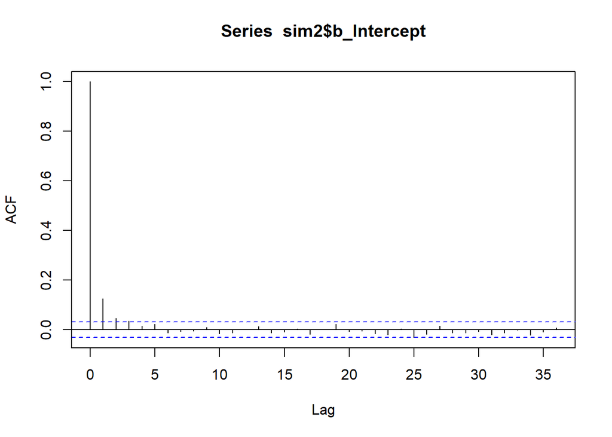

```r
acf(sim2$b_Intercept)
```

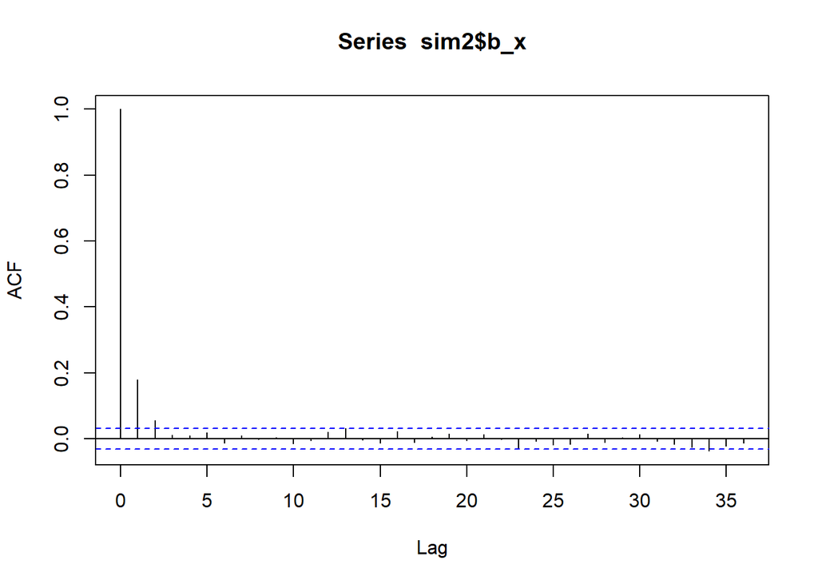

```r
acf(sim2$b_x)
```

Essentially 0 auto-correlation which is good. Large autocorrelations lead to less independent observations which can be a problem.

## 4.

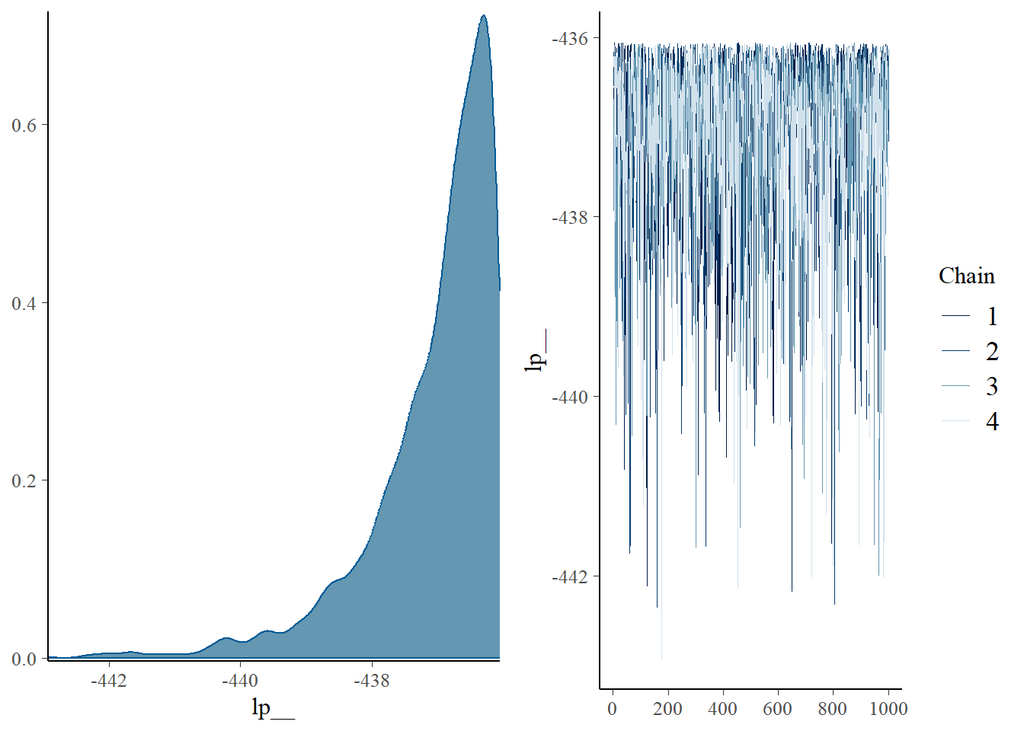

```r
plot(brm2 , variable = "lp__")
```

```r
rhat(brm2)
```

```
## b_Intercept         b_x      lprior        lp__
##    1.000892    1.000560    1.000269    1.000823
```

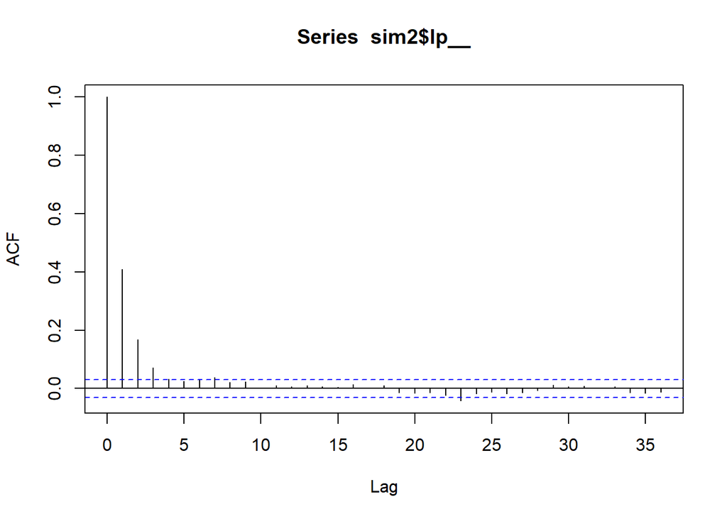

```r
acf(sim2$lp__)
```

It behaves slightly less nicely but still looks fine.

## 5.

We find a posterior mean and confidence intervals for $\lambda_{169}$ using the same procedure as in part B

```r
lambdas <- exp(sim2$b_Intercept + sim2$b_x*169)
mean(lambdas) #7.050769
```

```
## [1] 7.054898
```

```r
quantile(lambdas, c(0.025,0.975)) # 6.318982 7.817128
```

```
##     2.5%    97.5%
## 6.352961 7.810318
```

## 6.

Let $\bar{x}$ be the month where the expected number of killed van drivers is 10. I.e. the month $x_i$ that solves the equation
$$\exp(\alpha + \beta \bar{x}) = 10 \Leftrightarrow
(\log(10)-\alpha)/\beta = \bar{x} = \bar{x}$$
We can compute posterior confidence intervals and means easily as

```r
barx <- (log(10)-sim2$b_Intercept)/sim2$b_x
mean(barx)  %>% round(0) #69
```

```
## [1] 68
```

```r
quantile(barx, c(0.025,0.975))  %>% round(0) # 52 83
```

```
##  2.5% 97.5%
##    53    83
```

# D

We set up the stan code

```r
to_stan <- "data {
int N;
vector[N] x;
int y[N];
}
parameters {
real alpha;
real beta;
}
transformed parameters {
vector[N] lambda = exp(alpha + beta*x);
real bar_x = 1/beta*(log(10)-alpha);
}
model {
alpha ~ normal(3,25);
beta ~ normal(0,1);
y ~ poisson(lambda);
}
"
write(to_stan, file = "van.stan")
```

#9.

Drawing from the distribution

```r
library(rstan)
data <- list(x=before$x, y =before$y, N = length(before$y))
fitted <- stan("van.stan", data = data)
```

## 10.

```r
results <- (fitted %>% summary())$summary %>% as.data.frame()
results["beta",]
```

```
##              mean      se_mean           sd         2.5%          25%
## beta -0.003519654 1.735069e-05 0.0005068609 -0.004487561 -0.003867357
##               50%        75%        97.5%    n_eff     Rhat
## beta -0.003534417 -0.0031875 -0.002499871 853.3832 1.004059
```

## 11.

We find the following for $\lambda_{169}$

```r
results["lambda[169]",]
```

```
##                 mean     se_mean        sd     2.5%      25%      50%     75%
## lambda[169] 7.037568 0.008906275 0.3770908 6.342203 6.775882 7.026638 7.29412
##                97.5%    n_eff    Rhat
## lambda[169] 7.798645 1792.667 1.00183
```

Also close to what we had before.

## 12.

We find for $\bar{x}$ that

```r
results["bar_x",]
```

```
##          mean  se_mean       sd     2.5%      25%      50%      75%    97.5%
## bar_x 68.6126 0.220184 7.483761 53.14059 63.96496 68.76852 73.68758 82.14275
##         n_eff     Rhat
## bar_x 1155.23 1.002041
```

Which is also what we had before.